# Analysis of Phenological mismatch experiment 2021

SORTEE

2025-08-27

# 1. Introduction

This `.html` file goes along the script `1a_CatFoodExp2021_analysis_fitness.R` needed to reproduce the analysis about the analysis of phenological mismatch (experiment 2021) in the paper *Phenological mismatch affects individual fitness and population growth in the winter moth*, published in Proc Roy Soc B: https://doi.org/10.1098/rspb.2023.0414. This document can be used as a reference for result reproducibility (figures, tables, numbers). Nonetheless, it can be reproduced with the RMarkDown document `analysis_fitness.Rmd`. Note that the `.Rmd` file, as well as the main `.R` script, also contains custom reproducibility check functions that can be used by users to compare produced outputs to reference files.

- Manipulated timing of egg hatching of eggs from wild Mothers caught in 2020
- Either hatching on day of budburst (Day0), before (Day-4 to -1), or after (Day+1 to +5)
- Disentangle effects of photoperiod and food quality: photoperiod treatment (changing or constant)

Once all the necessary packages have been loaded, along with the data (which is loaded automatically from Dryad), let’s take a quick look at the data. We check that we have the right number of mothers (which should be 22) and the right number of females per area (which should be 3, 6, 6 and 7).

```r
# renaming TubeID as MotherID to match the terminology used in the Statistical section of the paper
d <- dplyr::rename(d, MotherID = TubeID)

# Number of mothers: should be 22
nb_mothers <- length(unique(d$MotherID))
print(nb_mothers)
```

```
## [1] 22
```

```r
checkReproducibilityValues(nb_mothers, 22) # checking reproducibility
```

```
## Expected value(s): 22
```

```
## nb_mothers correspond to the expected value(s)
```

```r
# Photoperiod and mismatch treatment coded in one variable
table(d$Treatment)
```

```
##
## ChangDay-1 ChangDay-2 ChangDay-3 ChangDay-4 ChangDay+1 ChangDay+2 ChangDay+3
##         66         65         66         65         66         66         66
## ChangDay+4 ChangDay+5  ChangDay0 ConstDay-2 ConstDay-4 ConstDay+2 ConstDay+4
##         66         66         66         63         61         66         66
##  ConstDay0
##         62
```

```r
# N females per Area
fem_per_area <- table(d[!duplicated(d$MotherID), "AreaShortName"])
print(fem_per_area)
```

```
## AreaShortName
## DO HV OH WA
##  3  6  6  7
```

```r
checkReproducibilityValues(fem_per_area, c(3, 6, 6, 7)) # checking reproducibility
```

```
## Expected value(s): 3 6 6 7
```

```
## fem_per_area correspond to the expected value(s)
```

Now we can start with the data analysis. Our first research question is : What are the fitness consequences of day to day timing (a)synchrony with budburst?

# 2. Survival analysis

## 2.1 Survival data

Let us start with the survival analysis. We create the object `d_surv` containing survival values (`Event` column). We check that we have the right number of caterpillars (976). Let us also observe the levels for each variable.

```r
d_surv <- d %>% mutate(PhotoTreat=gsub("(\\w+)Day.+","\\1",Treatment), MismTreat=gsub("\\w+(Day.+)","\\1",Treatment)) %>%
  select(MotherID, Treatment, PhotoTreat, MismTreat, CaterpillarID, DeadAprilDay, PupationAprilDay) %>%
  pivot_longer(cols=c(DeadAprilDay, PupationAprilDay), names_to="Info", values_to="TimeOfEvent") %>%
  filter(!is.na(TimeOfEvent)) %>%
  mutate(Event=ifelse(Info=="DeadAprilDay", 1, 0), Treatment=as.factor(Treatment), PhotoTreat=as.factor(ifelse(PhotoTreat=="Chang", "Changing", "Constant")),
         MismTreatf=as.factor(MismTreat), MotherID=as.factor(MotherID)) %>%
  mutate(Treatment=factor(Treatment, levels=c("ChangDay-4", "ChangDay-3", "ChangDay-2", "ChangDay-1", "ChangDay0", "ChangDay+1", "ChangDay+2", "ChangDay+3", "ChangDay+4",
                                              "ChangDay+5",  "ConstDay-4", "ConstDay-2", "ConstDay0", "ConstDay+2", "ConstDay+4")),
    MismTreatf=factor(MismTreat, levels=c("Day-4", "Day-3", "Day-2", "Day-1", "Day0", "Day+1", "Day+2", "Day+3", "Day+4", "Day+5")),
    MismTreat=as.numeric(gsub("Day(.+)","\\1",MismTreat))) %>%
  mutate(MismTreat1=MismTreat+5, # no negatives to be able to fit squared term
         MismTreat2=(MismTreat+5)^2) # squared term to add in model

  # To save d_surv after checking that it is OK (save_tables should be set to TRUE)
if(save_ref_outputs) write_rds(d_surv, "_results/ref/d_surv_expected.rds")
  # To check reproducibility with checked file
checkReproducibilityOutput(d_surv, "_results/ref/d_surv_expected.rds")
```

```
## d_surv corresponds to the expected output
```

```r
  # To read reference file for visual checking
if(read_ref_outputs)
  readReferenceFile("d_surv")

# Vidisha coded it as TimeOfEvent=DeadAprilDay or PupationAprilDay, with event=Died or Survived
head(d_surv)
```

```
## # A tibble: 6 × 11
##   MotherID Treatment  PhotoTreat MismTreat CaterpillarID Info  TimeOfEvent Event
##   <fct>    <fct>      <fct>          <dbl>         <dbl> <chr>       <dbl> <dbl>
## 1 16331    ChangDay-4 Changing          -4          5751 Dead…          50     1
## 2 16331    ChangDay-4 Changing          -4          5752 Dead…          50     1
## 3 16331    ConstDay-2 Constant          -2          5753 Dead…          62     1
## 4 16331    ConstDay-2 Constant          -2          5754 Dead…          50     1
## 5 16331    ConstDay-4 Constant          -4          5755 Dead…          50     1
## 6 16331    ConstDay-4 Constant          -4          5756 Dead…          50     1
## # ℹ 3 more variables: MismTreatf <fct>, MismTreat1 <dbl>, MismTreat2 <dbl>
```

```r
str(d_surv)
```

```
## tibble [976 × 11] (S3: tbl_df/tbl/data.frame)
##  $ MotherID     : Factor w/ 22 levels "16331","16347",..: 1 1 1 1 1 1 1 1 1 1 ...
##  $ Treatment    : Factor w/ 15 levels "ChangDay-4","ChangDay-3",..: 1 1 12 12 11 11 11 12 4 4 ...
##  $ PhotoTreat   : Factor w/ 2 levels "Changing","Constant": 1 1 2 2 2 2 2 2 1 1 ...
##  $ MismTreat    : num [1:976] -4 -4 -2 -2 -4 -4 -4 -2 -1 -1 ...
##  $ CaterpillarID: num [1:976] 5751 5752 5753 5754 5755 ...
##  $ Info         : chr [1:976] "DeadAprilDay" "DeadAprilDay" "DeadAprilDay" "DeadAprilDay" ...
##  $ TimeOfEvent  : num [1:976] 50 50 62 50 50 50 50 52 52 52 ...
##  $ Event        : num [1:976] 1 1 1 1 1 1 1 1 1 1 ...
##  $ MismTreatf   : Factor w/ 10 levels "Day-4","Day-3",..: 1 1 3 3 1 1 1 3 4 4 ...
##  $ MismTreat1   : num [1:976] 1 1 3 3 1 1 1 3 4 4 ...
##  $ MismTreat2   : num [1:976] 1 1 9 9 1 1 1 9 16 16 ...
```

```r
table(d_surv$MismTreat2)
```

```
##
##   1   4   9  16  25  36  49  64  81 100
## 126  66 128  66 128  66 132  66 132  66
```

```r
  # Automatic reproducibility check
nb_caterpillars <- length(unique(d_surv$CaterpillarID)) # should be 976
print(nb_caterpillars)
```

```
## [1] 976
```

```r
checkReproducibilityValues(nb_caterpillars, 976)
```

```
## Expected value(s): 976
```

```
## nb_caterpillars correspond to the expected value(s)
```

```r
levels(d_surv$Treatment)
```

```
##  [1] "ChangDay-4" "ChangDay-3" "ChangDay-2" "ChangDay-1" "ChangDay0"
##  [6] "ChangDay+1" "ChangDay+2" "ChangDay+3" "ChangDay+4" "ChangDay+5"
## [11] "ConstDay-4" "ConstDay-2" "ConstDay0"  "ConstDay+2" "ConstDay+4"
```

```r
levels(d_surv$PhotoTreat)
```

```
## [1] "Changing" "Constant"
```

```r
levels(d_surv$MismTreatf) # as factor or not? Marcel thinks not
```

```
##  [1] "Day-4" "Day-3" "Day-2" "Day-1" "Day0"  "Day+1" "Day+2" "Day+3" "Day+4"
## [10] "Day+5"
```

```r
levels(d_surv$MotherID)
```

```
##  [1] "16331" "16347" "16400" "16403" "16413" "16448" "16449" "16454" "16455"
## [10] "16465" "16470" "16481" "16525" "16547" "16590" "16609" "16612" "16624"
## [19] "16644" "16647" "16845" "16871"
```

```r
table(d_surv$TimeOfEvent)
```

```
##
##  50  52  54  56  58  62  63  65  67  68  70  72  75  77  79  82  84  86  89  91
## 201 142  76  39  68  27  23  15   2  58  86 106  71  29  20   7   2   1   2   1
```

```r
table(d_surv$Event) # this variable corresponds to "survival" as defined in the paper (e.g., the response variable in the first binomial mixed-effect model)
```

```
##
##   0   1
## 346 630
```

## 2.2 Survival probabilites

Then we can investigate survival probabilities in the table and figures below. `surv_probs` contains survival probability per mother and `surv_avg` the survival averaged over photoperiod treatments. Mother survival plotted according to the photoperiod treatment can be seen in the figure `raw_surv`, displayed below.

```r
surv_probs <- aggregate(Event~MismTreat + PhotoTreat + MotherID, d_surv, sum) # per mother
surv_probs$samplesize <- aggregate(Info~MismTreat + PhotoTreat + MotherID, d_surv, length)$Info
surv_probs$probs <- 100 - (surv_probs$Event/surv_probs$samplesize*100) # event = death
head(surv_probs)
```

```
##   MismTreat PhotoTreat MotherID Event samplesize    probs
## 1        -4   Changing    16331     3          3  0.00000
## 2        -3   Changing    16331     3          3  0.00000
## 3        -2   Changing    16331     3          3  0.00000
## 4        -1   Changing    16331     3          3  0.00000
## 5         0   Changing    16331     1          3 66.66667
## 6         1   Changing    16331     3          3  0.00000
```

```r
surv_avg <- Rmisc::summarySE(surv_probs, measurevar="probs", groupvars=c("MismTreat")) # average of two photoperiod treatments
surv_avg$samplesize <- aggregate(Info~MismTreat, d_surv, length)$Info
surv_avg
```

```
##    MismTreat  N     probs        sd       se        ci samplesize
## 1         -4 44  1.893939  8.961523 1.351000  2.724552        126
## 2         -3 22  7.575758 14.297734 3.048287  6.339260         66
## 3         -2 44  9.469697 17.386668 2.621139  5.286030        128
## 4         -1 22 27.272727 28.426762 6.060606 12.603720         66
## 5          0 43 39.922481 25.494977 3.887948  7.846196        128
## 6          1 22 62.121212 27.784992 5.923780 12.319175         66
## 7          2 44 56.818182 27.449315 4.138140  8.345354        132
## 8          3 22 60.606061 30.230794 6.445227 13.403583         66
## 9          4 44 56.060606 25.692202 3.873245  7.811143        132
## 10         5 22 42.424242 21.036170 4.484926  9.326915         66
```

```r
  # To save surv_avg after checking that it is OK (save_ref_outputs should be set to TRUE)
if(save_ref_outputs) write_rds(surv_avg, "_results/ref/surv_avg_expected.rds")
  # To check reproducibility with checked file
checkReproducibilityOutput(surv_avg, "_results/ref/surv_avg_expected.rds")
```

```
## surv_avg corresponds to the expected output
```

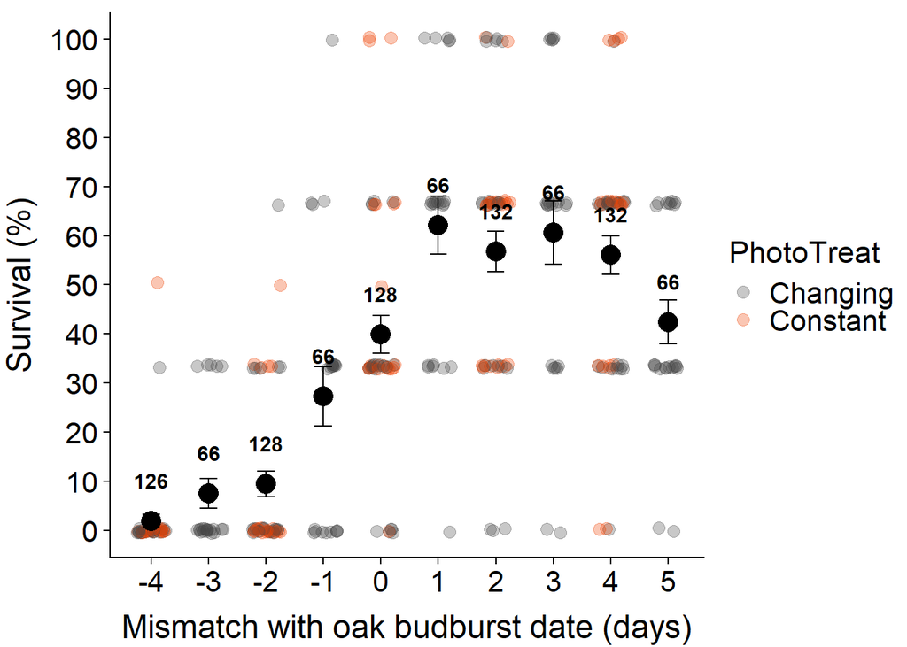

```r
  # To read reference file for visual checking
if(read_ref_outputs) readReferenceFile("surv_avg")

raw_surv <- ggplot(data=surv_avg, aes(x=MismTreat, y=probs))+
  scale_colour_manual(values=c("grey27", "orangered2"))+ #"dodgerblue4"
  geom_jitter(data=surv_probs, aes(col=PhotoTreat), alpha=0.3, size=3, height=0.5, width=0.25)+
  geom_point(size=5, col="black") +
  geom_errorbar(aes(ymax = probs+se, ymin=probs-se), width=0.3, col="black") +
  geom_text(aes(label=samplesize, y=probs+8.3), col="black", size=4,fontface="bold")+ # N caterpillars in each treatment
  labs(y="Survival (%)", x="Mismatch with oak budburst date (days)")+
  scale_y_continuous(breaks=seq(0,100, by=10))+ scale_x_continuous(breaks=seq(-4, 5, by=1))+
  theme(axis.title.y=element_text(size=18, vjust=2), axis.title.x=element_text(size=18, vjust=-0.5),
        axis.text=element_text(size=16), legend.text = element_text(size=16), legend.title=element_text(size=17))
raw_surv
```

```r
  # To save the figure
if(save_figures)
  ggsave(filename="_results/Survival_raw.png", plot=raw_surv , device="png", width=200, height=150, units="mm", dpi="print")

  # To save it as the reference file for reproducibility tests
if(save_ref_outputs)
  write_rds(raw_surv, "_results/ref/raw_surv_expected.rds")

  # To check correspondence with saved figure (reference)
checkReproducibilityOutput(obtained = raw_surv,
                           ref_path = "_results/ref/raw_surv_expected.rds", # the expected figure saved as a .RDS
                           ref_vis = "_results/Survival_raw.png", # the expected figure saved as a .PNG
                           print = F)
```

```
## raw_surv corresponds to the expected output
```

```r
# To read reference file for visual checking
if(read_ref_outputs) readReferenceFile("raw_surv")
```

## 2.3 Fit binomial models

Now we can fit binomial models to test if the probability of survival differs between treatments. Results from the final model can be seen below.

```r
glm1 <- glmer(Event ~ (MismTreat1 + MismTreat2)*PhotoTreat + (1|MotherID), family=binomial, data=d_surv,
              na.action="na.fail", control=glmerControl(calc.derivs=F)) # helps convergence
anova1 <- drop1(glm1,test="Chi") %>% as.data.frame
  # interaction not significant; the use of Chi-square test to determine statistical significance should be explicitly mention in the paper
anova1$mod <- "glm1"

glm2 <- update(glm1, ~ . -MismTreat1:PhotoTreat - MismTreat2:PhotoTreat) # simplify model
anova2 <- drop1(glm2,test="Chi") %>% as.data.frame #no effect of PhotoTreatment, but effect of MismTreat and MismTreat^2
anova2$mod <- "glm2"

### Final model ####
glm_final <- glm2
summary(glm_final)# Estimates are log odds
```

```
## Generalized linear mixed model fit by maximum likelihood (Laplace
##   Approximation) [glmerMod]
##  Family: binomial  ( logit )
## Formula: Event ~ MismTreat1 + MismTreat2 + PhotoTreat + (1 | MotherID)
##    Data: d_surv
## Control: glmerControl(calc.derivs = F)
##
##      AIC      BIC   logLik deviance df.resid
##   1026.1   1050.5   -508.0   1016.1      971
##
## Scaled residuals:
##     Min      1Q  Median      3Q     Max
## -9.5751 -0.8434  0.2023  0.8173  1.4480
##
## Random effects:
##  Groups   Name        Variance Std.Dev.
##  MotherID (Intercept) 0.06216  0.2493
## Number of obs: 976, groups:  MotherID, 22
##
## Fixed effects:
##                    Estimate Std. Error z value Pr(>|z|)
## (Intercept)         6.07087    0.57762  10.510  < 2e-16 ***
## MismTreat1         -1.69794    0.19122  -8.880  < 2e-16 ***
## MismTreat2          0.11153    0.01481   7.533 4.96e-14 ***
## PhotoTreatConstant -0.08599    0.16381  -0.525      0.6
## ---
## Signif. codes:  0 '***' 0.001 '**' 0.01 '*' 0.05 '.' 0.1 ' ' 1
##
## Correlation of Fixed Effects:
##             (Intr) MsmTr1 MsmTr2
## MismTreat1  -0.956
## MismTreat2   0.900 -0.984
## PhtTrtCnstn -0.052 -0.055  0.066
```

```r
glm_res <- summary(glm_final)$coefficients %>% as.data.frame

  # To save model outputs
if(save_tables) {
  write.csv(glm_res, file="_results/output_Surv_glmer.csv", row.names=T)
  write.csv(rbind(anova1, anova2), file="_results/anova_Surv_glmer.csv", row.names=T)
}

  # To save them as new references
if(save_ref_outputs) {
  write_rds(glm_res, file = "_results/ref/glm_surv_res_expected.rds")
  write_rds(rbind(anova1, anova2), file = "_results/ref/glm_surv_anova_expected.rds")
}

  # To check that model outputs match reference files
checkReproducibilityOutput(glm_res, "_results/ref/glm_surv_res_expected.rds")
```

```
## glm_res corresponds to the expected output
```

```r
checkReproducibilityOutput(rbind(anova1, anova2), "_results/ref/glm_surv_anova_expected.rds")
```

```
## rbind(anova1, anova2) corresponds to the expected output
```

```r
  # To read reference files for visual comparison
if(read_ref_outputs) {
  readReferenceFile("glm_surv_res")
  readReferenceFile("glm_surv_anova")
}
```

## 2.4 Get survival predictions

Now we can investigate model predictions in `p_surv` figure just below.

```r
### Get predictions ####
glm.pred <- d_surv[!duplicated(d_surv[,c("MotherID", "Treatment")]),] # each replicate assigned same prediction, so remove duplicates
glm.pred$pred <- predict(glm_final, newdata=glm.pred, type="response") # predictions are probability of dying now
glm.pred$survprob <- (1-glm.pred$pred)
aggregate(survprob~MismTreat, data=glm.pred, mean) # peak at Day2
```

```
##    MismTreat   survprob
## 1         -4 0.01177344
## 2         -3 0.04264512
## 3         -2 0.12685652
## 4         -1 0.25765391
## 5          0 0.41954199
## 6          1 0.52536101
## 7          2 0.59649538
## 8          3 0.59220008
## 9          4 0.55442650
## 10         5 0.43949515
```

```r
glm.pred$rel <- glm.pred$survprob/mean(filter(glm.pred, MismTreat==1)$survprob) # expressive relative to peak
head(glm.pred)
```

```
## # A tibble: 6 × 14
##   MotherID Treatment  PhotoTreat MismTreat CaterpillarID Info  TimeOfEvent Event
##   <fct>    <fct>      <fct>          <dbl>         <dbl> <chr>       <dbl> <dbl>
## 1 16331    ChangDay-4 Changing          -4          5751 Dead…          50     1
## 2 16331    ConstDay-2 Constant          -2          5753 Dead…          62     1
## 3 16331    ConstDay-4 Constant          -4          5755 Dead…          50     1
## 4 16331    ChangDay-1 Changing          -1          5759 Dead…          52     1
## 5 16331    ChangDay-3 Changing          -3          5763 Dead…          50     1
## 6 16331    ChangDay-2 Changing          -2          5765 Dead…          52     1
## # ℹ 6 more variables: MismTreatf <fct>, MismTreat1 <dbl>, MismTreat2 <dbl>,
## #   pred <dbl>, survprob <dbl>, rel <dbl>
```

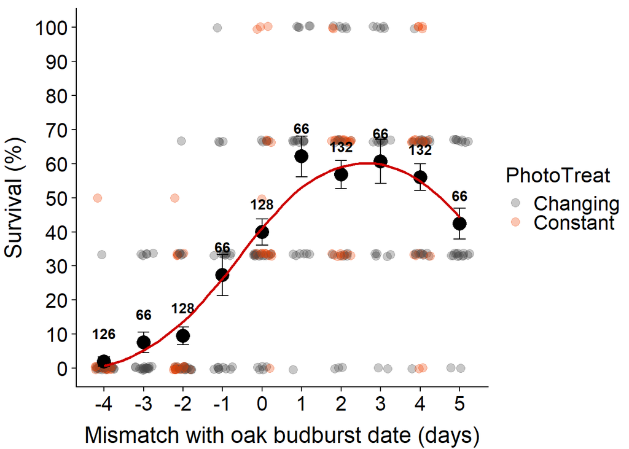

```r
### Visualize predictions ####
pred <- Rmisc::summarySE(glm.pred, measurevar="survprob", groupvars=c("MismTreat")) # average of two photoperiod treatments
pred$samplesize <- aggregate(CaterpillarID~MismTreat, data=d_surv, length)$CaterpillarID

# Add predictions to raw data figure
p_surv <- raw_surv + #geom_line(data=pred, aes(y=survprob*100)) +
  geom_smooth(data=pred, aes(y=survprob*100), se=F, col="red3")
p_surv
```

```r
  # To save the figure
if(save_figures)
  ggsave(filename="_results/Survival_wpred_rev.png", plot=p_surv, device="png", width=200, height=150, units="mm", dpi="print")

  # To save it as the reference file for reproducibility tests
if(save_ref_outputs)
  write_rds(p_surv, "_results/ref/p_surv_expected.rds")

  # To check correspondence with saved figure (reference)
checkReproducibilityOutput(obtained = p_surv,
                           ref_path = "_results/ref/p_surv_expected.rds", # the expected figure saved as a .RDS
                           ref_vis = "_resultsSurvival_wpred_rev.png", # the expected figure saved as a .PNG
                           print = F)
```

```
## p_surv corresponds to the expected output
```

```r
# To read the reference file for visual comparison
if(read_ref_outputs) readReferenceFile("p_surv")

rm(anova1, anova2, glm_res, glm1, glm2, pred, surv_probs, surv_avg, raw_surv) #cleanup
```

# 2. Pupation weight analysis

## 2.1 Pupation weight data

Let us pursue with the analysis of pupation weight. We create the object `d_pupa` containing only individuals that survived until pupation. We check that we have the right number of surviving individuals (346), which should make up 35% of the initial number of caterpillars.

```r
head(d)
```

```
## # A tibble: 6 × 19
##   ExperimentName YearCatch YearHatch MotherID AreaShortName  Site  Tree
##   <chr>              <dbl>     <dbl>    <dbl> <chr>         <dbl> <dbl>
## 1 CatFoodExp2021      2020      2022    16331 WA                1     1
## 2 CatFoodExp2021      2020      2022    16331 WA                1     1
## 3 CatFoodExp2021      2020      2022    16331 WA                1     1
## 4 CatFoodExp2021      2020      2022    16331 WA                1     1
## 5 CatFoodExp2021      2020      2022    16331 WA                1     1
## 6 CatFoodExp2021      2020      2022    16331 WA                1     1
## # ℹ 12 more variables: NovemberDate <dbl>, ClutchID <dbl>, CaterpillarID <dbl>,
## #   Treatment <chr>, HatchAprilDay <dbl>, DeadAprilDay <dbl>,
## #   PupationAprilDay <dbl>, PupaWeight_ingrams <dbl>, AdultNovDate <dbl>,
## #   AdultWeight_ingrams <dbl>, Sex <chr>, Remarks <chr>
```

```r
d_pupa <- d %>% mutate(PhotoTreat=gsub("(\\w+)Day.+","\\1",Treatment), MismTreat=gsub("\\w+(Day.+)","\\1",Treatment), PupaWeight=PupaWeight_ingrams*1000) %>%
  select(ExperimentName, MotherID, Treatment, PhotoTreat, MismTreat, CaterpillarID, PupationAprilDay, PupaWeight) %>%
  filter(!is.na(PupationAprilDay)) %>%
  mutate(Treatment=as.factor(Treatment), PhotoTreat=as.factor(ifelse(PhotoTreat=="Chang", "Changing", "Constant")), MismTreatf=as.factor(MismTreat), MotherID=as.factor(MotherID)) %>%
  mutate(Treatment=factor(Treatment, levels=c("ChangDay-4", "ChangDay-3", "ChangDay-2", "ChangDay-1", "ChangDay0", "ChangDay+1", "ChangDay+2", "ChangDay+3", "ChangDay+4",
                                              "ChangDay+5",  "ConstDay-4", "ConstDay-2", "ConstDay0", "ConstDay+2", "ConstDay+4")),
         MismTreatf=factor(MismTreat, levels=c("Day-4", "Day-3", "Day-2", "Day-1", "Day0", "Day+1", "Day+2", "Day+3", "Day+4", "Day+5")),
         MismTreat=as.numeric(gsub("Day(.+)","\\1",MismTreat))) %>%
  mutate(MismTreat1=MismTreat+5, # no negatives
         MismTreat2=(MismTreat+5)^2) # squared term to add in model

head(d_pupa)
```

```
## # A tibble: 6 × 11
##   ExperimentName MotherID Treatment  PhotoTreat MismTreat CaterpillarID
##   <chr>          <fct>    <fct>      <fct>          <dbl>         <dbl>
## 1 CatFoodExp2021 16331    ChangDay0  Changing           0          5771
## 2 CatFoodExp2021 16331    ChangDay0  Changing           0          5772
## 3 CatFoodExp2021 16331    ConstDay0  Constant           0          5773
## 4 CatFoodExp2021 16331    ChangDay+2 Changing           2          5779
## 5 CatFoodExp2021 16331    ChangDay+3 Changing           3          5781
## 6 CatFoodExp2021 16331    ChangDay+3 Changing           3          5782
## # ℹ 5 more variables: PupationAprilDay <dbl>, PupaWeight <dbl>,
## #   MismTreatf <fct>, MismTreat1 <dbl>, MismTreat2 <dbl>
```

```r
n_survived <- nrow(d_pupa)
print(n_survived) # 346 individuals survived until pupation
```

```
## [1] 346
```

```r
checkReproducibilityValues(n_survived, 346) # automatic reproducibility checking
```

```
## Expected value(s): 346
```

```
## n_survived correspond to the expected value(s)
```

```r
percent_survived <- n_survived/nrow(d)*100
print(percent_survived) # ~35%
```

```
## [1] 35.45082
```

```r
checkReproducibilityValues(percent_survived, 35.45082) # automatic reproducibility checking
```

```
## Expected value(s): 35.45082
```

```
## percent_survived correspond to the expected value(s)
```

## 2.2 Visualize pupation weight data

```r
weight <- Rmisc::summarySE(d_pupa, measurevar="PupaWeight", groupvars=c("MismTreat", "PhotoTreat"))
weight$pos <- ifelse(is.na(weight$se)==T, 0, weight$se) # position of sample size labels
weight
```

```
##    MismTreat PhotoTreat  N PupaWeight        sd       se        ci      pos
## 1         -4   Changing  1   45.00000        NA       NA       NaN 0.000000
## 2         -4   Constant  1   76.00000        NA       NA       NaN 0.000000
## 3         -3   Changing  5   48.80000  7.328028 3.277194  9.098949 3.277194
## 4         -2   Changing  7   36.00000  4.690416 1.772811  4.337911 1.772811
## 5         -2   Constant  5   48.20000  9.203260 4.115823 11.427357 4.115823
## 6         -1   Changing 18   37.88889  9.743105 2.296472  4.845132 2.296472
## 7          0   Changing 21   39.85714 11.359074 2.478753  5.170589 2.478753
## 8          0   Constant 30   43.76667  7.916301 1.445312  2.955995 1.445312
## 9          1   Changing 41   41.17073  9.723432 1.518545  3.069094 1.518545
## 10         2   Changing 37   37.05405 11.296376 1.857113  3.766399 1.857113
## 11         2   Constant 38   39.42105 10.681207 1.732721  3.510826 1.732721
## 12         3   Changing 40   30.97500 10.477051 1.656567  3.350723 1.656567
## 13         4   Changing 35   29.17143 10.466995 1.769245  3.595539 1.769245
## 14         4   Constant 39   31.92308  9.793619 1.568234  3.174724 1.568234
## 15         5   Changing 28   28.60714 11.226092 2.121532  4.353024 2.121532
```

```r
  # Saving reference weight file
if(save_ref_outputs) write_rds(weight, "_results/ref/weight_expected.rds")
  # Reproducibility checking
checkReproducibilityOutput(weight, "_results/ref/weight_expected.rds")
```

```
## weight corresponds to the expected output
```

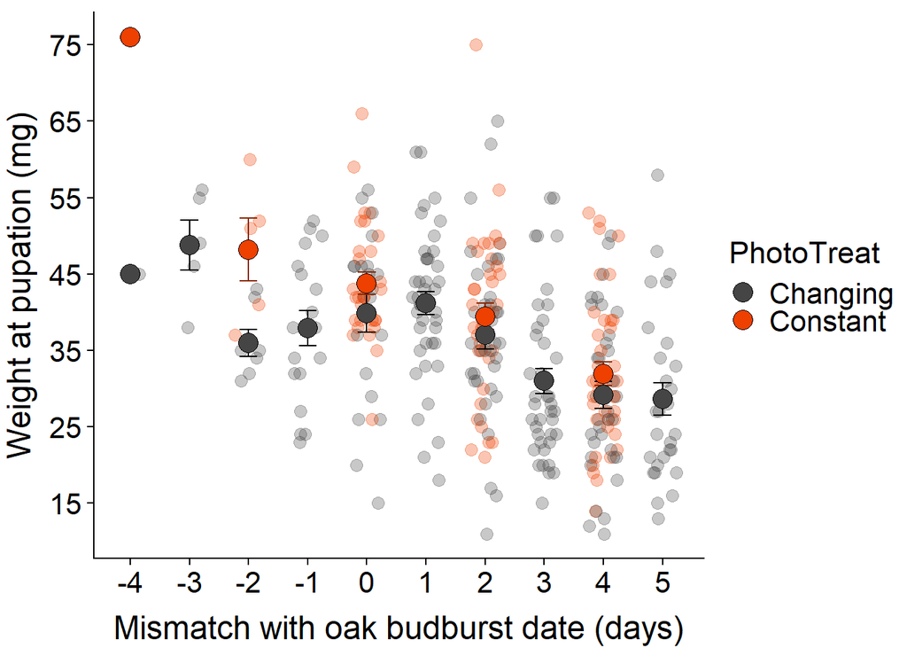

```r
  # To read the reference file for visual comparison
if(read_ref_outputs) readReferenceFile("weight")


raw_weight <- ggplot(data=weight, aes(x=MismTreat, y=PupaWeight, col=PhotoTreat, fill=PhotoTreat))+
  scale_colour_manual(values=c("grey27", "orangered2"))+ #"dodgerblue4"
  scale_fill_manual(values=c("grey27", "orangered2"))+
  geom_jitter(data=d_pupa, aes(col=PhotoTreat), alpha=0.3, size=3, height=0, width=0.25)+ #alpha=0.3, size=2, height=0, width=0.25
  geom_errorbar(data=filter(weight, PhotoTreat=="Changing"), aes(ymax = PupaWeight+se, ymin=PupaWeight-se), width=0.3, col="black") +
  geom_errorbar(data=filter(weight, PhotoTreat=="Constant"), aes(ymax = PupaWeight+se, ymin=PupaWeight-se), width=0.3, col="orangered4") +
  geom_point(size=5, shape=21, col="black")+
  #geom_text(data=filter(weight, PhotoTreat=="Changing"),aes(label=N, y=PupaWeight-pos-2.3), col="black", size=4, fontface="bold")+
  #geom_text(data=filter(weight, PhotoTreat=="Constant"),aes(label=N, y=PupaWeight+pos+2.3), col="black", size=4, fontface="bold")+
  labs(y="Weight at pupation (mg)", x="Mismatch with oak budburst date (days)")+
  scale_y_continuous(breaks=seq(15,75, by=10))+ scale_x_continuous(breaks=seq(-4, 5, by=1))+
  theme(axis.title.y=element_text(size=18, vjust=2), axis.title.x=element_text(size=18, vjust=-0.5),
        axis.text=element_text(size=16), legend.text = element_text(size=16), legend.title=element_text(size=17))
raw_weight
```

```r
  # To save the figure
if(save_figures)
  ggsave(filename="_results/PupWeight_raw.png", plot=raw_weight , device="png", width=200, height=150, units="mm", dpi="print")

  # To save it as the reference file for reproducibility tests
if(save_ref_outputs)
  write_rds(raw_weight, "_results/ref/raw_weight_expected.rds")

  # To check correspondence with saved figure (reference)
checkReproducibilityOutput(obtained = raw_weight,
                           ref_path = "_results/ref/raw_weight_expected.rds", # the expected figure saved as a .RDS
                           ref_vis = "_results/PupWeight_raw.png", # the expected figure saved as a .PNG
                           print = F)
```

```
## raw_weight corresponds to the expected output
```

```r
  # To read the reference file for visual comparison
if(read_ref_outputs) readReferenceFile("raw_weight")
```

## 2.3 Fit linear mixed model

```r
lm1 <- lmer(PupaWeight ~ (MismTreat1 + MismTreat2)*PhotoTreat + (1|MotherID), data=d_pupa)
anova1 <- anova(lm1) %>% as.data.frame() # interaction not significant
anova1$mod <- "lm1"

lm2 <- update(lm1, ~ . - MismTreat1:PhotoTreat - MismTreat2:PhotoTreat) # simplify model
anova2 <- anova(lm2) %>% as.data.frame() # Squared mismatch not significant
anova2$mod <- "lm2"

lm3 <- update(lm2, ~ . - MismTreat2) # simplify model
anova3 <- anova(lm3) %>% as.data.frame() # PhotoTreat and MismTreat significant
anova3$mod <- "lm3"

# Still there if exclude first time point with low sample size?
lm4 <- lmer(PupaWeight ~ -1 + MismTreat1 + PhotoTreat + (1|MotherID), data=filter(d_pupa, MismTreat!=-4))
anova(lm4) # yes
```

```
## Type III Analysis of Variance Table with Satterthwaite's method
##            Sum Sq Mean Sq NumDF  DenDF F value    Pr(>F)
## MismTreat1   7466  7465.6     1 328.70  76.963 < 2.2e-16 ***
## PhotoTreat  61917 30958.4     2 301.19 319.149 < 2.2e-16 ***
## ---
## Signif. codes:  0 '***' 0.001 '**' 0.01 '*' 0.05 '.' 0.1 ' ' 1
```

```r
### Final model ####
lm_final <- lm3
summary(lm_final)
```

```
## Linear mixed model fit by REML. t-tests use Satterthwaite's method [
## lmerModLmerTest]
## Formula: PupaWeight ~ MismTreat1 + PhotoTreat + (1 | MotherID)
##    Data: d_pupa
##
## REML criterion at convergence: 2582.3
##
## Scaled residuals:
##     Min      1Q  Median      3Q     Max
## -2.4238 -0.6583 -0.0430  0.6150  3.5393
##
## Random effects:
##  Groups   Name        Variance Std.Dev.
##  MotherID (Intercept)  9.917   3.149
##  Residual             97.746   9.887
## Number of obs: 346, groups:  MotherID, 22
##
## Fixed effects:
##                    Estimate Std. Error      df t value Pr(>|t|)
## (Intercept)          52.643      2.108 273.602  24.968  < 2e-16 ***
## MismTreat1           -2.506      0.269 330.950  -9.314  < 2e-16 ***
## PhotoTreatConstant    3.301      1.144 330.084   2.886  0.00416 **
## ---
## Signif. codes:  0 '***' 0.001 '**' 0.01 '*' 0.05 '.' 0.1 ' ' 1
##
## Correlation of Fixed Effects:
##             (Intr) MsmTr1
## MismTreat1  -0.895
## PhtTrtCnstn -0.193  0.017
```

```r
lm_res <- summary(lm_final)$coefficients %>% as.data.frame

plot(lm_final) #equal variance? ok
```

[figure not shown]

```r
qqnorm(resid(lm_final)) #normally distributed? ok
qqline(resid(lm_final))
```

[figure not shown]

```r
# To save model outputs
if(save_tables) {
  write.csv(lm_res, file="_results/output_PupaWeight_lmer.csv", row.names=T)
  write.csv(rbind(anova1, anova2, anova3), file="_results/anova_PupaWeight_lmer.csv", row.names=T)
}

# To save them as new references
if(save_ref_outputs) {
  write_rds(lm_res, file = "_results/ref/lm_weight_res_expected.rds")
  write_rds(rbind(anova1, anova2, anova3), file = "_results/ref/lm_weight_anova_expected.rds")
}

# To check that model outputs match reference files
checkReproducibilityOutput(lm_res, "_results/ref/lm_weight_res_expected.rds")
```

```
## lm_res corresponds to the expected output
```

```r
checkReproducibilityOutput(rbind(anova1, anova2, anova3), "_results/ref/lm_weight_anova_expected.rds")
```

```
## rbind(anova1, anova2, anova3) corresponds to the expected output
```

```r
# To read reference files for visual comparison
if(read_ref_outputs) {
  readReferenceFile("lm_weight_res")
  readReferenceFile("lm_weight_anova")
}

### Get predictions ####
lm.pred <- d_pupa[!duplicated(d_pupa[,c("MotherID", "Treatment")]),] # each replicate assigned same prediction, so remove duplicates
lm.pred$pred <- predict(lm_final, newdata=lm.pred, type="response")
head(lm.pred)
```

```
## # A tibble: 6 × 12
##   ExperimentName MotherID Treatment  PhotoTreat MismTreat CaterpillarID
##   <chr>          <fct>    <fct>      <fct>          <dbl>         <dbl>
## 1 CatFoodExp2021 16331    ChangDay0  Changing           0          5771
## 2 CatFoodExp2021 16331    ConstDay0  Constant           0          5773
## 3 CatFoodExp2021 16331    ChangDay+2 Changing           2          5779
## 4 CatFoodExp2021 16331    ChangDay+3 Changing           3          5781
## 5 CatFoodExp2021 16331    ConstDay+2 Constant           2          5785
## 6 CatFoodExp2021 16347    ChangDay-1 Changing          -1          5796
## # ℹ 6 more variables: PupationAprilDay <dbl>, PupaWeight <dbl>,
## #   MismTreatf <fct>, MismTreat1 <dbl>, MismTreat2 <dbl>, pred <dbl>
```

## 2.4 Visualize weight predictions

```r
pred1 <- Rmisc::summarySE(lm.pred, measurevar="pred", groupvars=c("MismTreat", "PhotoTreat")) # significant effect of photoperiod, so show separate means
```

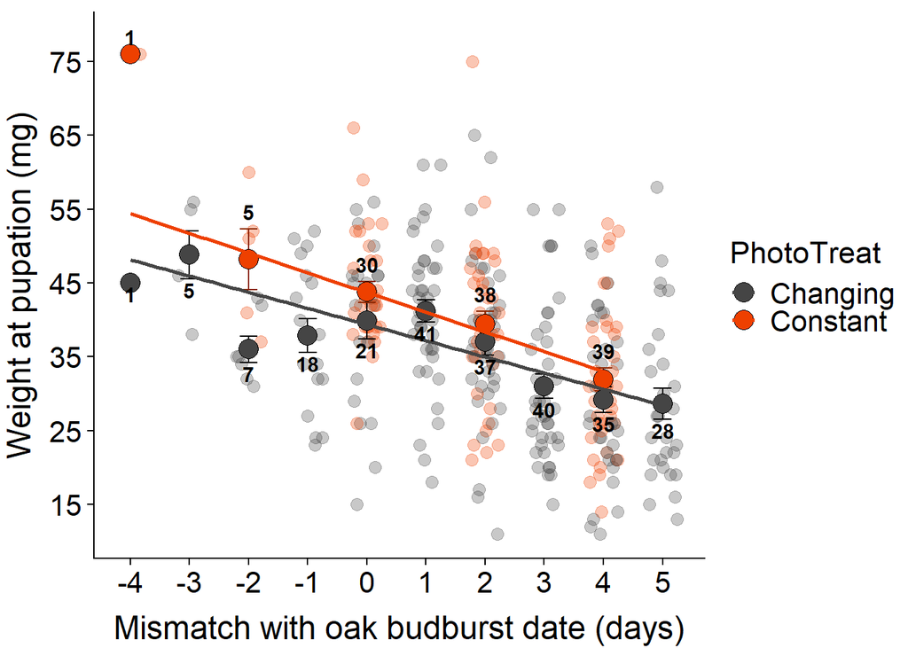

```r
pred1$samplesize <- weight$N
pred1$pos <- ifelse(is.na(pred1$se)==T, 0, pred1$se) # position of sample size labels

## add predictions to raw data figure
p_weight <- raw_weight + #geom_line(data=pred1, aes(y=pred)) +
  geom_smooth(data=pred1, aes(y=pred, col=PhotoTreat), se=F, method=lm)+
  geom_text(data=filter(weight, PhotoTreat=="Changing"),aes(label=N, y=PupaWeight-pos-1.5), col="black", size=4, fontface="bold")+
  geom_text(data=filter(weight, PhotoTreat=="Constant"),aes(label=N, y=PupaWeight+pos+2.3), col="black", size=4, fontface="bold")
p_weight
```

```r
# To save the figure
if(save_figures)
  ggsave(filename="_results/PupWeight_wpred_rev.png", plot=p_weight, device="png", width=200, height=150, units="mm", dpi="print")

# To save it as the reference file for reproducibility tests
if(save_ref_outputs)
  write_rds(p_weight, "_results/ref/p_weight_expected.rds")

# To check correspondence with saved figure (reference)
checkReproducibilityOutput(obtained = p_weight,
                           ref_path = "_results/ref/p_weight_expected.rds", # the expected figure saved as a .RDS
                           ref_vis = "_results/PupWeight_wpred_rev.png", # the expected figure saved as a .PNG
                           print = F)
```

```
## p_weight corresponds to the expected output
```

```r
# To read the reference file for visual comparison
if(read_ref_outputs) readReferenceFile("p_weight")
```

# 3. Making figure 2

Now we can make figure 2 that contains both survival and weight data and predictions.

```r
# Making figure 2 entirely code-based
# common_legend in ggarrange() does not work properly here
  # (to get legend on the right)
# so we use a trick by combining ggpubr and cowplot
# we extract the legend, which is considered as a different figure
# then we arrange figure position with cowplot::plot_grid()
fig2_layout <-
  ggpubr::ggarrange(p_surv + theme(legend.position = "none"),
                    p_weight + theme(legend.position = "none"),
                    nrow = 1,
                    labels = c("(a)", "(b)"),
                    font.label = list(face = "italic"))
fig2 <-
  cowplot::plot_grid(fig2_layout,
                     # extracting legend here
                     ggpubr::get_legend(p_weight),
                     # to arrange positions
                     rel_widths = c(0.6, 0.1)) +
  bgcolor('white')
  # sate save_figures to TRUE to save the figure again
if(save_figures)
  ggplot2::ggsave(filename = "_results/figure_2.png",
                  fig2,
                  device = "png",
                  width = 400,
                  height = 150,
                  units = "mm",
                  dpi = "print")

  # sate save_ref_outputs to TRUE to save it as a reference file
  # for reproducibility checking
if(save_ref_outputs)
  write_rds(fig2, file = "_results/ref/fig2_expected.rds")

# Checking reproducibility
  # !! CheckReproducibilityOuput() function does not work for complex figures generated with ggpubr/cowplot
  # Please visually refer to the reference figure for checking that it matches the output
message('fig2 should match the file saved as _results/ref/fig_2_expected.rds')
```

```
## fig2 should match the file saved as _results/ref/fig_2_expected.rds
```

```r
message('Set read_ref_outputs to TRUE and run the following line to plot the reference file:')
```

```
## Set read_ref_outputs to TRUE and run the following line to plot the reference file:
```

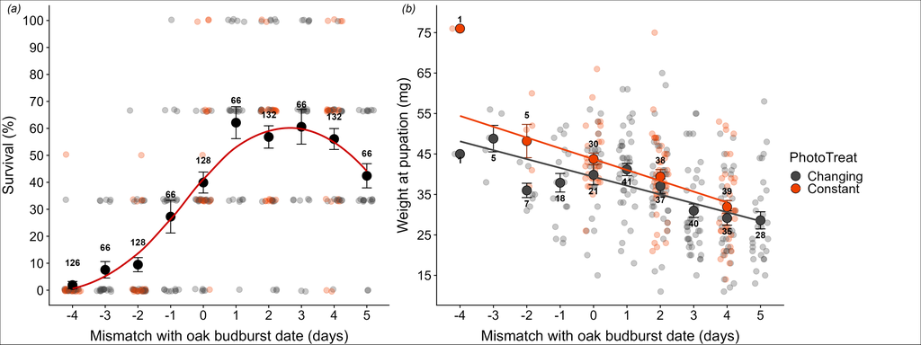

Figure 2. Fitness consequences of individual phenological mismatch. Check paper for more details.

```r
if(read_ref_outputs)
  readReferenceFile("fig2")
```

# 4. Get fitness curve

## 4.1 Fit GLM

Now we can estimate the relative fitness curve for phenological mismatch, combining the predicted survival probabilities and the predicted pupation weights (as a proxy for fecundity) for each phenological mismatch treatment. Let us start with fitting the corresponding models.

```r
# Don't care about PhotoTreat effect, drop from models
glm_fit <- glmer(Event ~ MismTreat1 + MismTreat2 + (1 | MotherID), family="binomial", data=d_surv)
lm_fit <- lmer(PupaWeight ~ MismTreat1 + (1 | MotherID), data=d_pupa)

### Get predictions to use for curve ####
glm.fit <- d_surv[!duplicated(d_surv[,c("MotherID", "MismTreatf")]),] # each replicate assigned same prediction, so remove duplicates
glm.fit$pred <- predict(glm_fit, newdata=glm.fit, type="response") # predictions are probability of dying now
glm.fit$survpred <- (1-glm.fit$pred)

lm.fit <- d_pupa[!duplicated(d_pupa[,c("MotherID", "MismTreatf")]),] # each replicate assigned same prediction, so remove duplicates
lm.fit$pred <- predict(lm_fit, newdata=lm.fit, type="response")

head(glm.fit) # pred = probability of dying, survpred=1-pred, 220 observations = 22 mothers * 10 MismTreat groups
```

```
## # A tibble: 6 × 13
##   MotherID Treatment  PhotoTreat MismTreat CaterpillarID Info  TimeOfEvent Event
##   <fct>    <fct>      <fct>          <dbl>         <dbl> <chr>       <dbl> <dbl>
## 1 16331    ChangDay-4 Changing          -4          5751 Dead…          50     1
## 2 16331    ConstDay-2 Constant          -2          5753 Dead…          62     1
## 3 16331    ChangDay-1 Changing          -1          5759 Dead…          52     1
## 4 16331    ChangDay-3 Changing          -3          5763 Dead…          50     1
## 5 16331    ConstDay0  Constant           0          5768 Dead…          54     1
## 6 16331    ChangDay+1 Changing           1          5775 Dead…          54     1
## # ℹ 5 more variables: MismTreatf <fct>, MismTreat1 <dbl>, MismTreat2 <dbl>,
## #   pred <dbl>, survpred <dbl>
```

```r
head(lm.fit) # pred=predicted weight from lmer, only 154 observations
```

```
## # A tibble: 6 × 12
##   ExperimentName MotherID Treatment  PhotoTreat MismTreat CaterpillarID
##   <chr>          <fct>    <fct>      <fct>          <dbl>         <dbl>
## 1 CatFoodExp2021 16331    ChangDay0  Changing           0          5771
## 2 CatFoodExp2021 16331    ChangDay+2 Changing           2          5779
## 3 CatFoodExp2021 16331    ChangDay+3 Changing           3          5781
## 4 CatFoodExp2021 16347    ChangDay-1 Changing          -1          5796
## 5 CatFoodExp2021 16347    ConstDay0  Constant           0          5802
## 6 CatFoodExp2021 16347    ChangDay+1 Changing           1          5804
## # ℹ 6 more variables: PupationAprilDay <dbl>, PupaWeight <dbl>,
## #   MismTreatf <fct>, MismTreat1 <dbl>, MismTreat2 <dbl>, pred <dbl>
```

## 4.2 Fit curve to absolute fitness

We then estimate fitness by multiplying predictions of survival probabilities with expected pupation weights in `RelFit`table (`Fit` and `Fit2`columns, see comments below).

```r
RelFit <- merge(glm.fit[,c("MotherID", "MismTreat", "survpred")], lm.fit[,c("MotherID", "MismTreat", "pred")], by=c("MotherID", "MismTreat"), all=T)
colnames(RelFit)[c(3,4)] <- c("survpred", "pupwpred")
RelFit$Fit <- RelFit$survpred*RelFit$pupwpred # multiply absolute values
head(RelFit) # can only do for 154 observations, clutches with >=1 caterpillar surviving until pupation
```

```
##   MotherID MismTreat    survpred pupwpred      Fit
## 1    16331        -4 0.008593864       NA       NA
## 2    16331        -3 0.032910738       NA       NA
## 3    16331        -2 0.096472415       NA       NA
## 4    16331        -1 0.211193054       NA       NA
## 5    16331         0 0.349192615 40.30861 14.07547
## 6    16331         1 0.462179172       NA       NA
```

```r
table(RelFit$MismTreat, is.na(RelFit$Fit)) # for the other clutches, fitness = 0
```

```
##
##      FALSE TRUE
##   -4     2   20
##   -3     5   17
##   -2     8   14
##   -1    13    9
##   0     22    0
##   1     21    1
##   2     22    0
##   3     20    2
##   4     21    1
##   5     20    2
```

```r
RelFit$Fit2 <- ifelse(is.na(RelFit$Fit)==T, 0, RelFit$Fit)
```

## 4.3 LOESS model to describe the curve

We then express fitness at each day of mismatch with oak budburst date relatively to the fitness peak (which occurs at day 2) in the `rel` column of `relFit` object and average over treatments in `RelFit_means`. We also use a LOESS model to fit a curve to the data (see `curve` just below).

```r
loess_mod <- loess(Fit2~ -1 + MismTreat,  data=RelFit)
summary(loess_mod)
```

```
## Call:
## loess(formula = Fit2 ~ -1 + MismTreat, data = RelFit)
##
## Number of Observations: 220
## Equivalent Number of Parameters: 4.22
## Residual Standard Error: 3.967
## Trace of smoother matrix: 4.58  (exact)
##
## Control settings:
##   span     :  0.75
##   degree   :  2
##   family   :  gaussian
##   surface  :  interpolate      cell = 0.2
##   normalize:  TRUE
##  parametric:  FALSE
## drop.square:  FALSE
```

```r
curve <- RelFit[!duplicated(RelFit[,c("MismTreat")]),] %>% select(MismTreat)
curve$pred <- predict(loess_mod, newdata=curve)
curve <- arrange(curve, MismTreat)
curve # peak at day2
```

```
##    MismTreat       pred
## 1         -4 -0.4747885
## 2         -3  0.7497291
## 3         -2  3.7961331
## 4         -1  8.5495785
## 5          0 15.1864116
## 6          1 19.9490357
## 7          2 20.9520241
## 8          3 19.7090164
## 9          4 16.5282083
## 10         5 11.4523050
```

```r
curve$rel <- curve$pred/filter(curve, MismTreat==2)$pred # expressive relative to peak

RelFit$rel <- RelFit$Fit2/mean(filter(RelFit, MismTreat==2)$Fit2)

RelFit_means <- Rmisc::summarySE(RelFit, measurevar="rel", groupvars=c("MismTreat"))
#RelFit_means$samplesize <- aggregate(MotherID~MismTreat, data=d_pupa, length)$MotherID # number of caterpillars curve is based on
RelFit_means$samplesize <- aggregate(MotherID~MismTreat, data=d_surv, length)$MotherID # number of caterpillars curve is based on = all
RelFit_means$curve <- curve$rel
head(RelFit_means)
```

```
##   MismTreat  N         rel          sd          se          ci samplesize
## 1        -4 22 0.002546425 0.008334757 0.001776976 0.003695424        126
## 2        -3 22 0.022873146 0.043550345 0.009284965 0.019309141         66
## 3        -2 22 0.104890716 0.143081493 0.030505077 0.063438780        128
## 4        -1 22 0.324281543 0.280084430 0.059714201 0.124182479         66
## 5         0 22 0.799977563 0.085999807 0.018335220 0.038130178        128
## 6         1 22 0.923835199 0.223935400 0.047743188 0.099287394         66
##         curve
## 1 -0.02266075
## 2  0.03578314
## 3  0.18118217
## 4  0.40805502
## 5  0.72481835
## 6  0.95212929
```

```r
  # To save RelFit_means
if(save_tables) write.csv(RelFit_means, file="_results/RelFitness_rev.csv", row.names=F)
  # To save it as a new reference
if(save_ref_outputs) write_rds(RelFit_means, file = "_results/ref/RelFit_means_expected.rds")
  # To check that the table matches the reference file
checkReproducibilityOutput(RelFit_means, "_results/ref/RelFit_means_expected.rds")
```

```
## RelFit_means corresponds to the expected output
```

```r
  # To read the reference file for visual comparison
if(read_ref_outputs) readReferenceFile("RelFit_means")
```

## 4.4 Visualize predictions

Finally, we visualize fitness predictions in the `p_relfit` curve below.

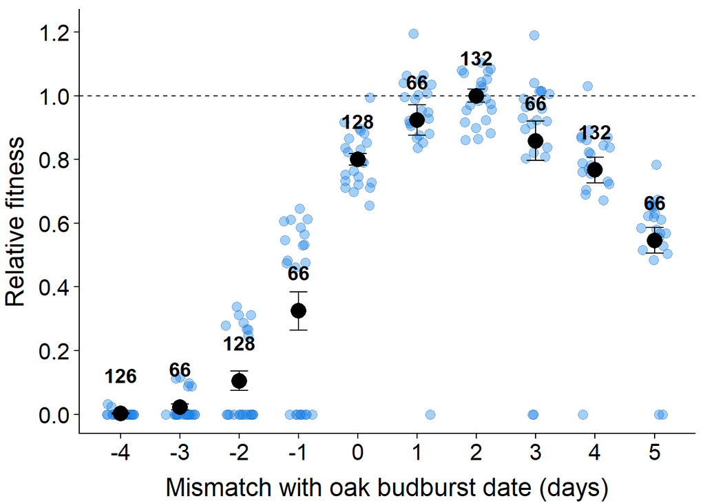

```r
### Visualize predictions ####
p_relfit <- ggplot(data=RelFit, aes(x=MismTreat, y=rel)) +
  geom_jitter(size=3, alpha=0.4, height=0, width=0.25, shape=21, fill="dodgerblue2", col="dodgerblue4")+
  geom_point(data=RelFit_means, size=5) +
  geom_errorbar(data=RelFit_means, aes(ymax = rel+se, ymin=rel-se), width=0.3) +
  #geom_line(data=curve, aes(y=pred), col="darkred", size=1)+
  #geom_smooth(data=curve, se=F, col="red3", size=1)+ # makes it look more like a smooth line, but otherwise exactly the same as using geom_line
  geom_text(data=RelFit_means,aes(label=samplesize, y=rel+0.12), col="black", size=5, fontface="bold")+ # number of caterpillars
  geom_hline(yintercept=1, linetype="dashed")+
  labs(y="Relative fitness", x="Mismatch with oak budburst date (days)")+
  scale_y_continuous(lim=c(0,1.21), breaks=seq(0,1.6, by=0.2))+ scale_x_continuous(breaks=seq(-4,5, by=1))+ #lim=c(-0.1,1.3)
  theme(legend.position="none")+
  theme(axis.title.y=element_text(size=18, vjust=2), axis.title.x=element_text(size=18, vjust=-0.5),
        axis.text=element_text(size=16), legend.text = element_text(size=16), legend.title=element_text(size=17))
p_relfit
```

```r
# To save the figure
if(save_figures)
  ggsave(filename="_results/FitnessCurve_rev.png", plot=p_relfit, device="png", width=200, height=150, units="mm", dpi="print")

# To save it as the reference file for reproducibility tests
if(save_ref_outputs)
  write_rds(p_relfit, "_results/ref/p_relfit_expected.rds")

# To check correspondence with saved figure (reference)
checkReproducibilityOutput(obtained = p_relfit,
                           ref_path = "_results/ref/p_relfit_expected.rds", # the expected figure saved as a .RDS
                           ref_vis = "_results/FitnessCurve_rev.png", # the expected figure saved as a .PNG
                           print = F)
```

```
## p_relfit corresponds to the expected output
```

```r
# To read the reference file for visual comparison
if(read_ref_outputs) readReferenceFile("p_relfit")
```

## 4.5 Average fitness loss per day

Finally, we can calculate the average daily fitness loss for individuals that hatched either before or after the ‘peak’ day (`fitness_loss_hatchedEarlier` or `fitness_loss_hatchedLater`, respectively).

```r
  # 1. Hatching earlier than budburst date
fitness_loss_hatchedEarlier <-
RelFit_means %>%
  dplyr::select(MismTreat, curve) %>%
  dplyr::filter(MismTreat <= 2) %>%
  dplyr::rename("pred_fitness" = "curve") %>%
  # What would have been the mean fitness if hatched one day later?
  mutate(lagged_fitness = lead(pred_fitness)) %>%
  mutate(fitness_loss = lagged_fitness - pred_fitness)

fitness_loss_hatchedEarlier %>% print
```

```
##   MismTreat pred_fitness lagged_fitness fitness_loss
## 1        -4  -0.02266075     0.03578314   0.05844388
## 2        -3   0.03578314     0.18118217   0.14539903
## 3        -2   0.18118217     0.40805502   0.22687285
## 4        -1   0.40805502     0.72481835   0.31676334
## 5         0   0.72481835     0.95212929   0.22731093
## 6         1   0.95212929     1.00000000   0.04787071
## 7         2   1.00000000             NA           NA
```

```r
  # Mean value ? Should be 14%
fitness_loss_earlier <- na.omit(fitness_loss_hatchedEarlier$fitness_loss)
mean_fitness_loss_earlier <- exp(mean(log(fitness_loss_earlier))) %>% round(2)
checkReproducibilityValues(mean_fitness_loss_earlier, 0.14)
```

```
## Expected value(s): 0.14
```

```
## mean_fitness_loss_earlier correspond to the expected value(s)
```

```r
  # Max value ? Should be 32%
fitness_loss_hatchedEarlier %>% dplyr::slice(which.max(fitness_loss)) # corresponds to day -1
```

```
##   MismTreat pred_fitness lagged_fitness fitness_loss
## 1        -1     0.408055      0.7248184    0.3167633
```

```r
max_fitness_loss_earlier <- fitness_loss_hatchedEarlier$fitness_loss %>% max(na.rm = T) %>% round(2)
checkReproducibilityValues(max_fitness_loss_earlier, 0.32)
```

```
## Expected value(s): 0.32
```

```
## max_fitness_loss_earlier correspond to the expected value(s)
```

```r
  # 2. Hatching later than budburst date
fitness_loss_hatchedLater <-
RelFit_means %>%
  dplyr::select(MismTreat, curve) %>%
  dplyr::filter(MismTreat >= 2) %>%
  dplyr::rename("pred_fitness" = "curve") %>%
  # What would have been the mean fitness if hatched one day later?
  mutate(lagged_fitness = lag(pred_fitness)) %>%
  mutate(fitness_loss = lagged_fitness - pred_fitness)

fitness_loss_hatchedLater %>% print
```

```
##   MismTreat pred_fitness lagged_fitness fitness_loss
## 1         2    1.0000000             NA           NA
## 2         3    0.9406736      1.0000000   0.05932638
## 3         4    0.7888597      0.9406736   0.15181388
## 4         5    0.5465966      0.7888597   0.24226315
```

```r
  # Mean value ? Should be 13% (although reported as 6% in paper)
fitness_loss_Later <- na.omit(fitness_loss_hatchedLater$fitness_loss)
mean_fitness_loss_Later <- exp(mean(log(fitness_loss_Later))) %>% round(2)
checkReproducibilityValues(mean_fitness_loss_Later, 0.13)
```

```
## Expected value(s): 0.13
```

```
## mean_fitness_loss_Later correspond to the expected value(s)
```

```r
  # Max value ? Should be 32%
fitness_loss_hatchedLater %>% dplyr::slice(which.max(fitness_loss)) # corresponds to day -1
```

```
##   MismTreat pred_fitness lagged_fitness fitness_loss
## 1         5    0.5465966      0.7888597    0.2422631
```

```r
max_fitness_loss_Later <- fitness_loss_hatchedLater$fitness_loss %>% max(na.rm = T) %>% round(2)
checkReproducibilityValues(max_fitness_loss_Later, 0.24)
```

```
## Expected value(s): 0.24
```

```
## max_fitness_loss_Later correspond to the expected value(s)
```

```r
  # To save output tables
if(save_tables) {
  write.csv(fitness_loss_hatchedEarlier, file="_results/fitness_loss_hatchedEarlier.csv")
  write.csv(fitness_loss_hatchedLater, file="_results/fitness_loss_hatchedEarlier.csv")
}
  # To save them as new references
if(save_ref_outputs) {
  write_rds(fitness_loss_hatchedEarlier, file = "_results/ref/fitness_loss_hatchedEarlier_expected.rds")
  write_rds(fitness_loss_hatchedLater, file = "_results/ref/fitness_loss_hatchedLater_expected.rds")
}
  # To check that tables match the reference files
checkReproducibilityOutput(fitness_loss_hatchedEarlier, "_results/ref/fitness_loss_hatchedEarlier_expected.rds")
```

```
## fitness_loss_hatchedEarlier corresponds to the expected output
```

```r
checkReproducibilityOutput(fitness_loss_hatchedLater, "_results/ref/fitness_loss_hatchedLater_expected.rds")
```

```
## fitness_loss_hatchedLater corresponds to the expected output
```

```r
  # To read reference files for visual comparison
if(read_ref_outputs) {
  readReferenceFile("fitness_loss_hatchedEarlier")
  readReferenceFile("fitness_loss_hatchedLater")
}
```